# R Graphics

# Plot

The plot() function is used to draw points (markers) in a diagram.

The function takes parameters for specifying points in the diagram.

Parameter 1 specifies points on the x-axis.

Parameter 2 specifies points on the y-axis.

At its simplest, you can use the plot() function to plot two numbers against each other:

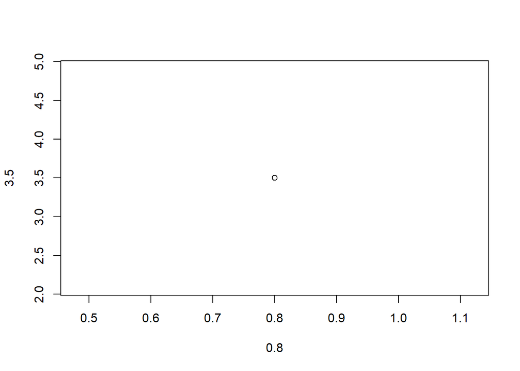

```r
# Draw one point in the diagram, at position (0.8) and position (3.5):

plot(0.8, 3.5)
```

To draw more points, use vectors:

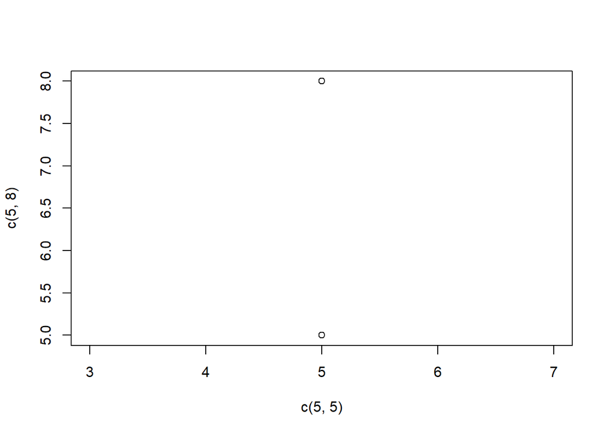

```r
# Draw two points in the diagram, one at position (5,5) and one in position (5,8):

plot(c(5, 5), c(5, 8))
```

# Multiple Points

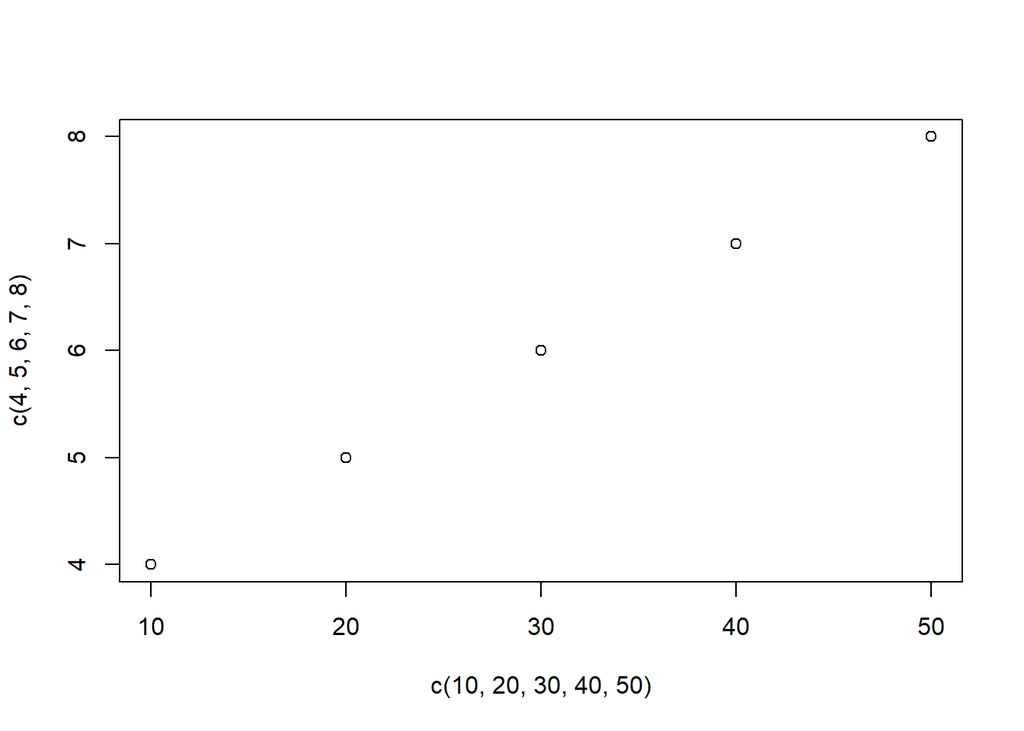

```r
# plot as many points as you like, just make sure you have the same number of points in both axis:

plot(c(10, 20, 30, 40, 50), c(4,5,6,7,8))
```

For better organization, when you have many values, it is better to use variables:

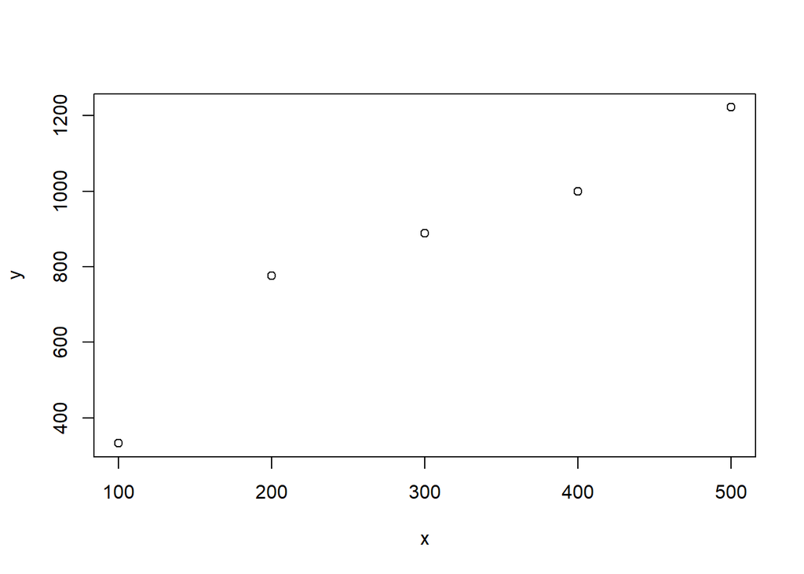

```r
x <- c(100, 200, 300, 400, 500)
y <- c(333, 777, 888, 999, 1222)

plot(x, y)
```

# Sequences of Points

If you want to draw dots in a sequence, on both the x-axis and the y-axis, use the : operator:

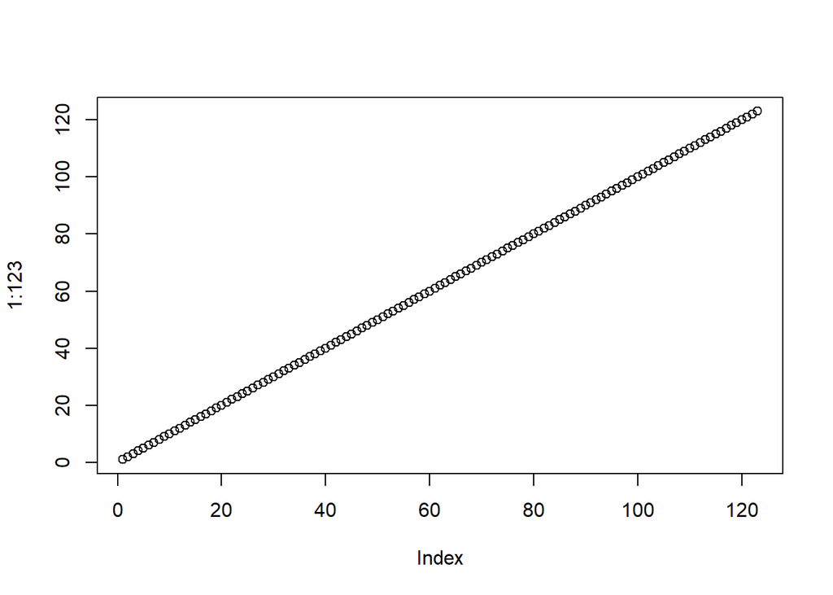

```r
plot(1:123)
```

# Draw a Line

The plot() function also takes a type parameter with the value l to draw a line to connect all the points in the diagram:

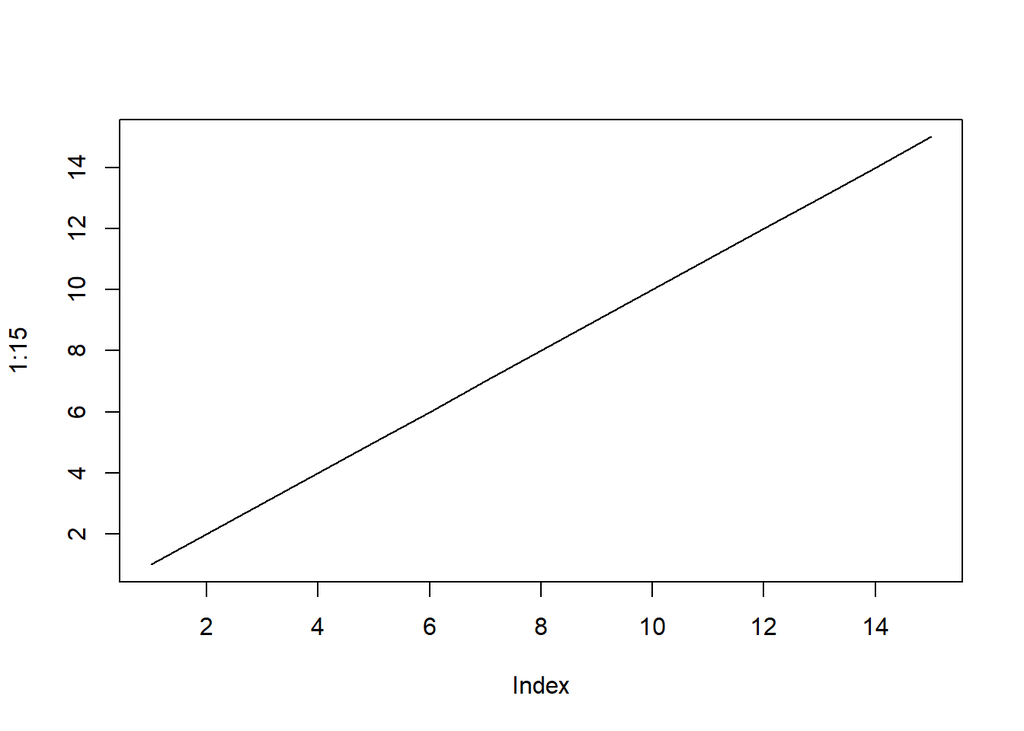

```r
plot(1:15, type="l")
```

# Plot Labels

The plot() function also accept other parameters, such as main, xlab and ylab if you want to customize the graph with a main title and different labels for the x and y-axis:

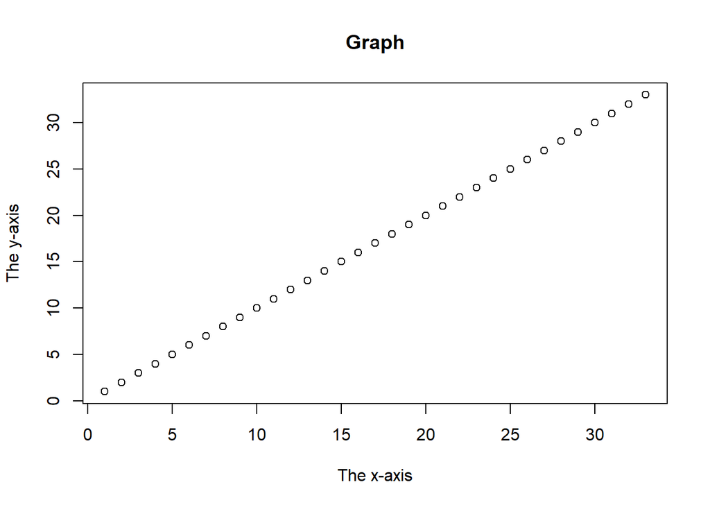

```r
plot(1:33, main="Graph", xlab="The x-axis", ylab="The y-axis")
```

# Graph Appearance

There are many other parameters you can use to change the appearance of the points.

# Colors

Use col=“color” to add a color to the points:

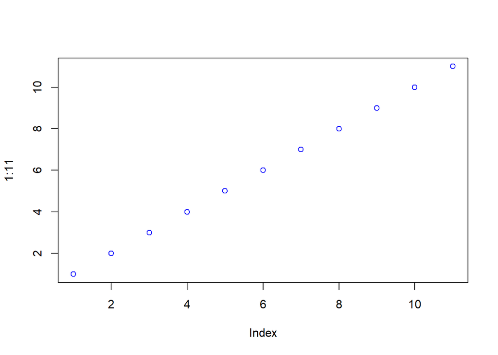

```r
plot(1:11, col="blue")
```

# Size

Use cex=number to change the size of the points (1 is default, while 0.5 means 50% smaller, and 2 means 100% larger):

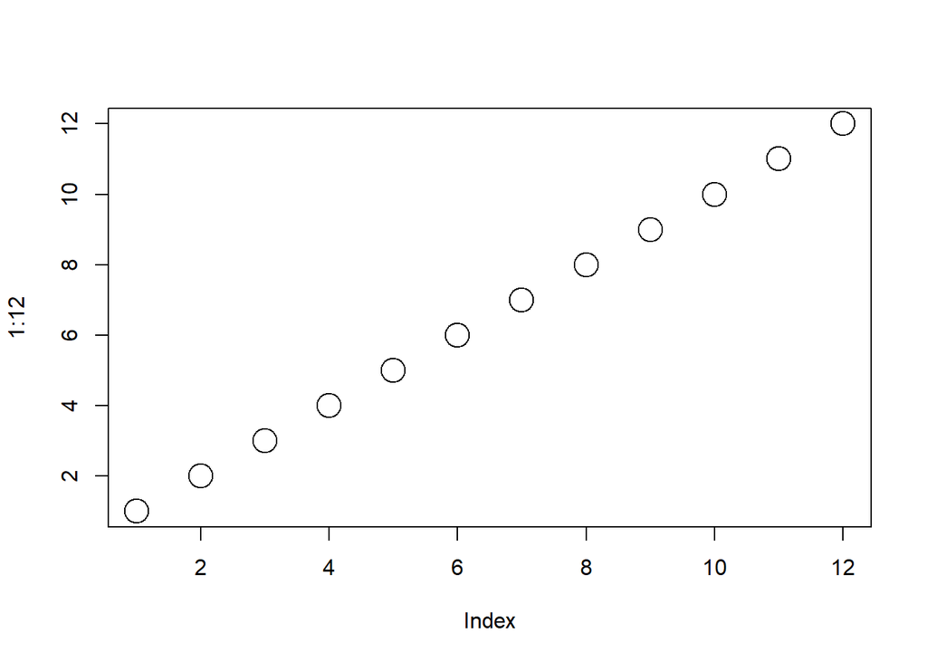

```r
plot(1:12, cex=2.5)
```

# Point Shape

Use pch with a value from 0 to 25 to change the point shape format:

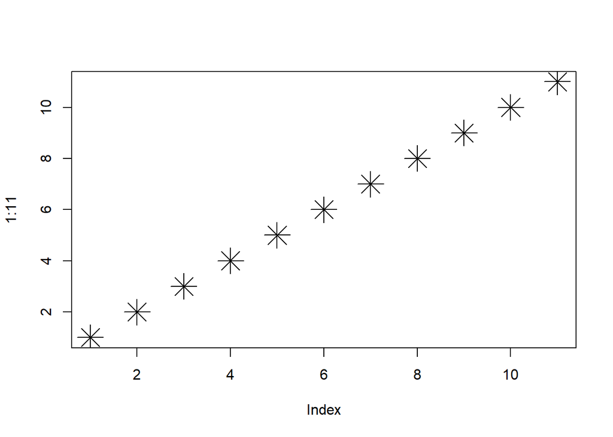

```r
plot(1:11, pch=8, cex=2.8)
```

# Line Graphs

A line graph has a line that connects all the points in a diagram.

To create a line, use the plot() function and add the type parameter with a value of “l”:

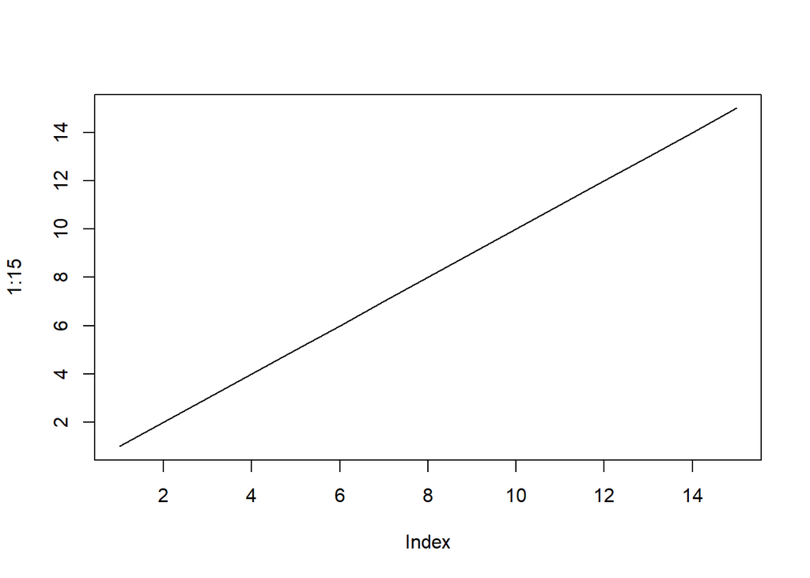

```r
plot(1:15, type="l")
```

# Line Color

The line color is black by default. To change the color, use the col parameter:

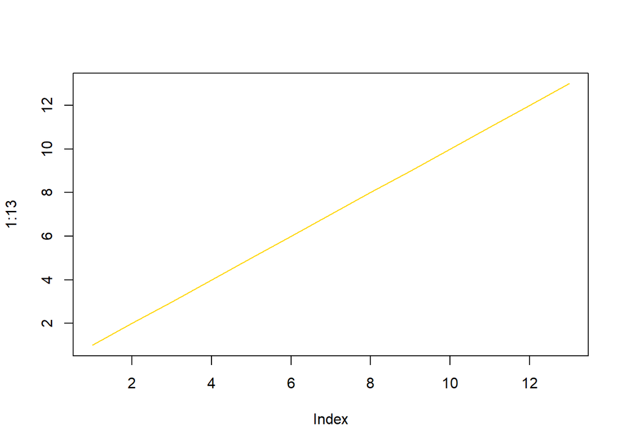

```r
plot(1:13, type="l", col="gold")
```

# Line Width

To change the width of the line, use the lwd parameter (1 is default, while 0.5 means 50% smaller, and 2 means 100% larger):

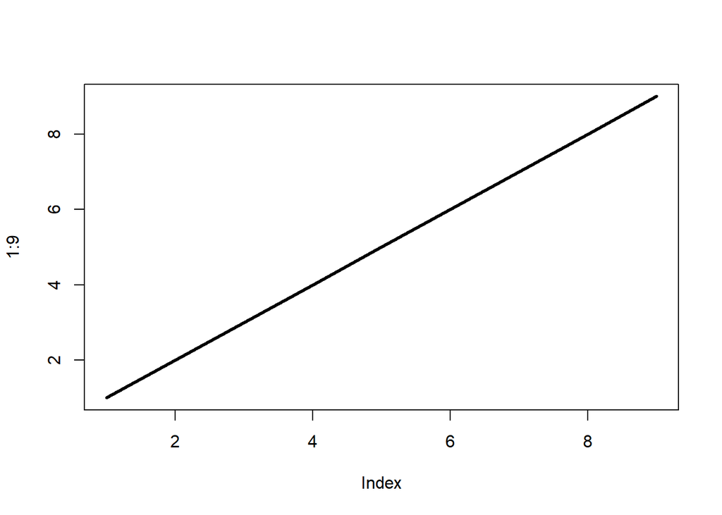

```r
plot(1:9, type="l", lwd=3)
```

# Line Styles

The line is solid by default. Use the lty parameter with a value from 0 to 6 to specify the line format.

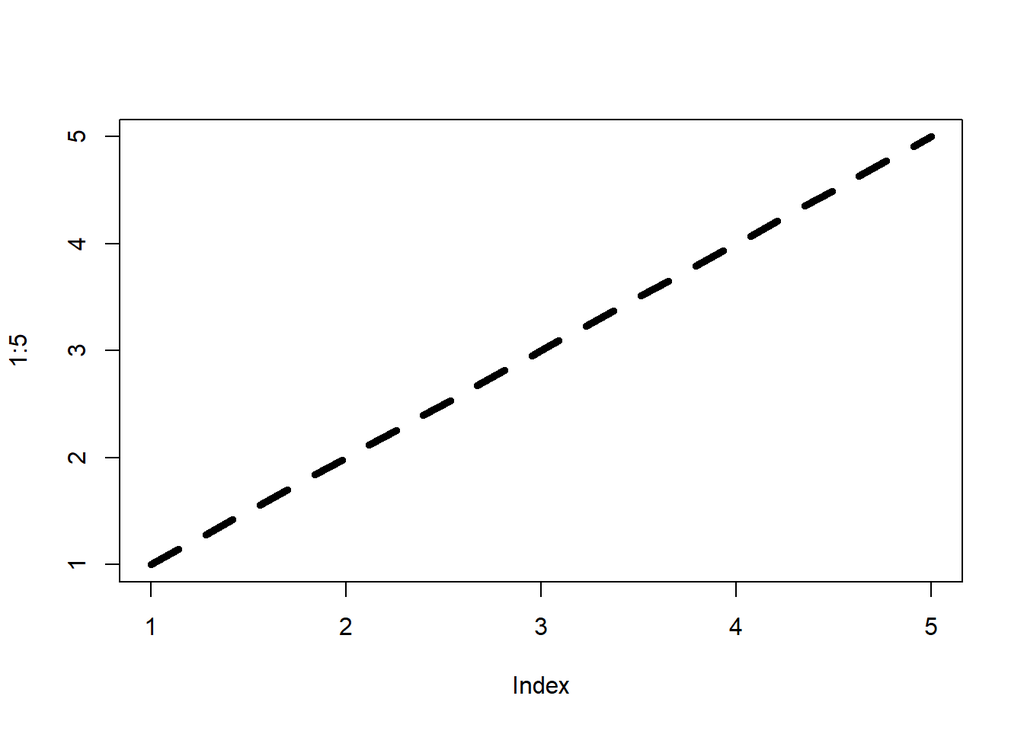

```r
plot(1:5, type="l", lwd=5, lty=2)
```

Available parameter values for lty:

0 removes the line 1 displays a solid line 2 displays a dashed line 3 displays a dotted line 4 displays a “dot dashed” line 5 displays a “long dashed” line 6 displays a “two dashed” line

# Multiple Lines

To display more than one line in a graph, use the plot() function together with the lines() function:

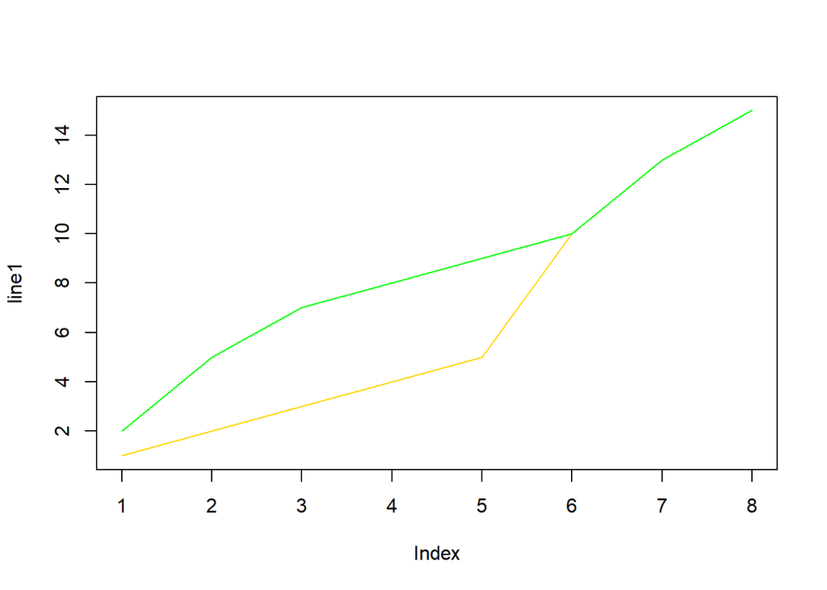

```r
line1 <- c(1,2,3,4,5,10,13,15)
line2 <- c(2,5,7,8,9,10,13,15)

plot(line1, type = "l", col = "gold")
lines(line2, type="l", col = "green")
```

# Scatter Plots

You learned from the Plot chapter that the plot() function is used to plot numbers against each other.

A “scatter plot” is a type of plot used to display the relationship between two numerical variables, and plots one dot for each observation.

It needs two vectors of same length, one for the x-axis (horizontal) and one for the y-axis (vertical):

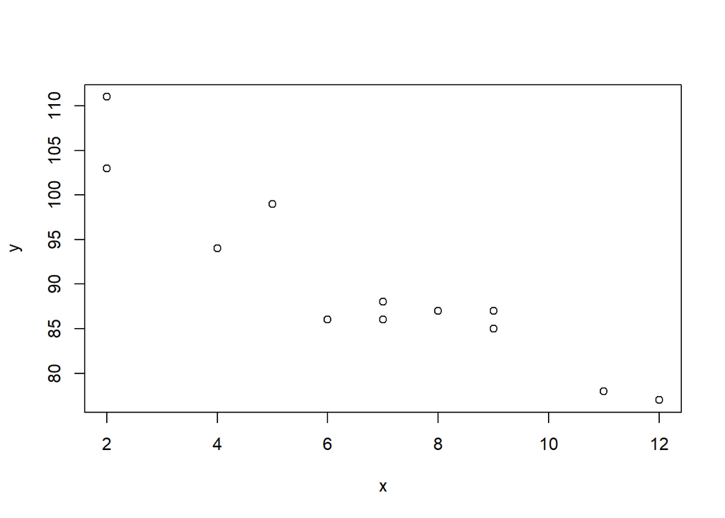

```r
x <- c(5,7,8,7,2,2,9,4,11,12,9,6)
y <- c(99,86,87,88,111,103,87,94,78,77,85,86)

plot(x, y)
```

The observation in the example above should show the result of 12 cars passing by.

That might not be clear for someone who sees the graph for the first time, so let’s add a header and different labels to describe the scatter plot better:

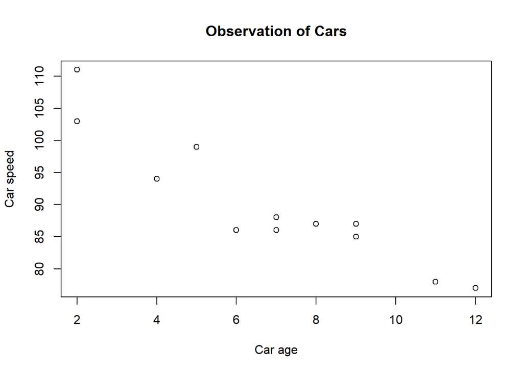

```r
x <- c(5,7,8,7,2,2,9,4,11,12,9,6)
y <- c(99,86,87,88,111,103,87,94,78,77,85,86)

plot(x, y, main="Observation of Cars", xlab="Car age", ylab="Car speed")
```

To recap, the observation in the example above is the result of 12 cars passing by.

The x-axis shows how old the car is.

The y-axis shows the speed of the car when it passes.

Are there any relationships between the observations?

It seems that the newer the car, the faster it drives, but that could be a coincidence, after all we only registered 12 cars.

# Compare Plots

In the example above, there seems to be a relationship between the car speed and age, but what if we plot the observations from another day as well? Will the scatter plot tell us something else?

To compare the plot with another plot, use the points() function:

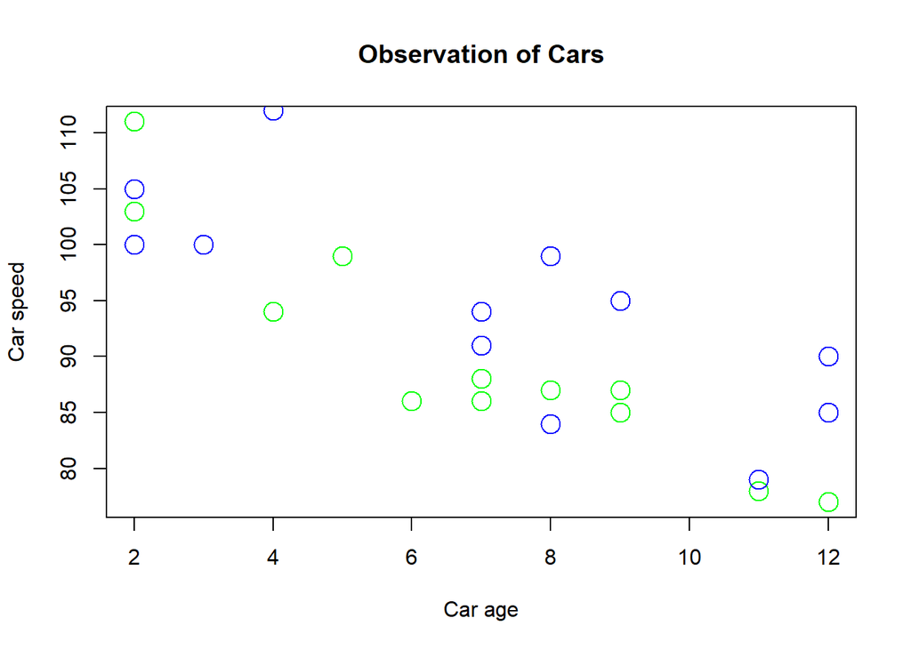

```r
# Draw two plots on the same figure:

# day one, the age and speed of 12 cars:
x1 <- c(5,7,8,7,2,2,9,4,11,12,9,6)
y1 <- c(99,86,87,88,111,103,87,94,78,77,85,86)

# day two, the age and speed of 15 cars:
x2 <- c(2,2,8,1,15,8,12,9,7,3,11,4,7,14,12)
y2 <- c(100,105,84,105,90,99,90,95,94,100,79,112,91,80,85)

plot(x1, y1, main="Observation of Cars", xlab="Car age", ylab="Car speed", col="green", cex=2)
points(x2, y2, col="blue", cex=2)
```

Conclusion of observation: By comparing the two plots, I think it is safe to say that they both gives us the same conclusion: the newer the car, the faster it drives.

# Pie Charts

A pie chart is a circular graphical view of data.

Use the pie() function to draw pie charts:

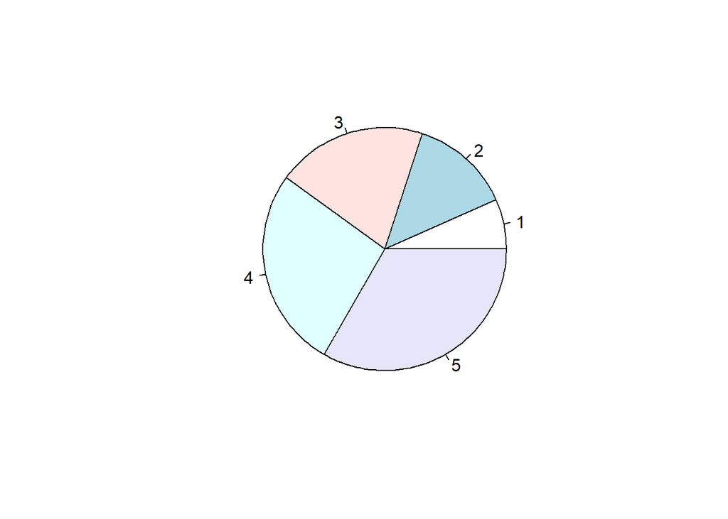

```r
# Create a vector of pies
x <- c(10,20,30,40,50)

# Display the pie chart
pie(x)
```

# Example Explained

By default, the plotting of the first pie starts from the x-axis and move counterclockwise.

Note: The size of each pie is determined by comparing the value with all the other values, by using this formula:

The value divided by the sum of all values: x/sum(x)

# Start Angle

You can change the start angle of the pie chart with the init.angle parameter.

The value of init.angle is defined with angle in degrees, where default angle is 0.

Start the first pie at 45 degrees:

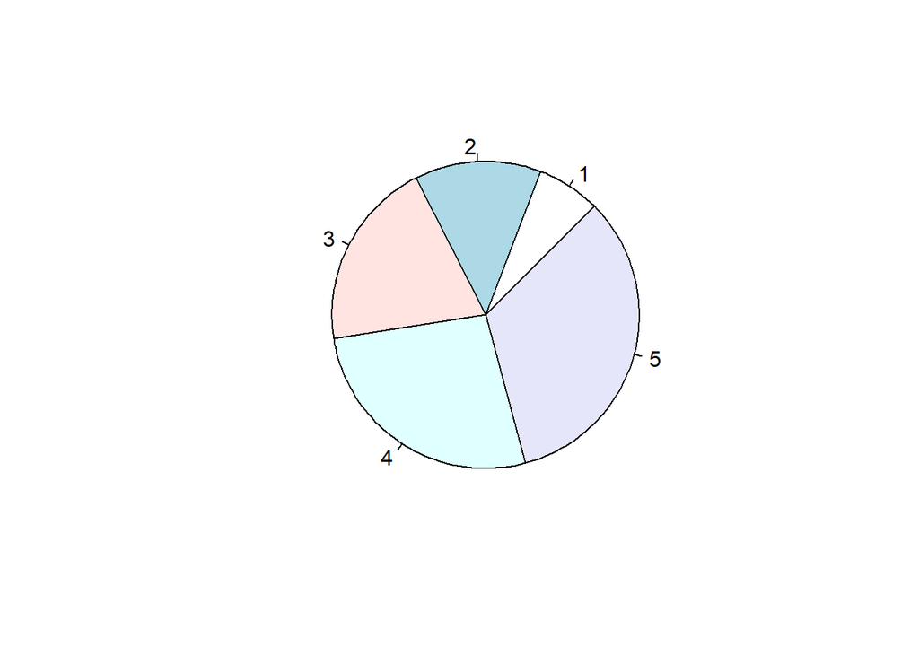

```r
# Create a vector of pies
x <- c(10,20,30,40,50)

# Display the pie chart and start the first pie at 90 degrees
pie(x, init.angle = 45)
```

# Labels and Header

Use the label parameter to add a label to the pie chart, and use the main parameter to add a header:

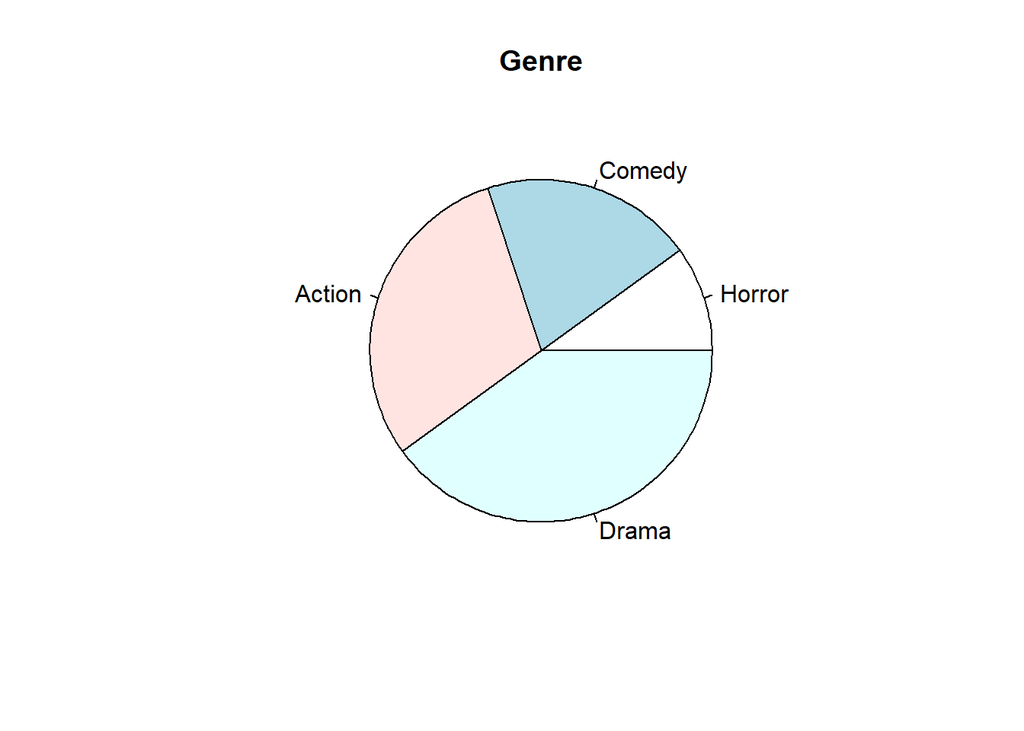

```r
# Create a vector of pies
x <- c(10,20,30,40)

# Create a vector of labels
movie_genre <- c("Horror", "Comedy", "Action", "Drama")

# Display the pie chart with labels
pie(x, label = movie_genre, main = "Genre")
```

# Colors

You can add a color to each pie with the col parameter:

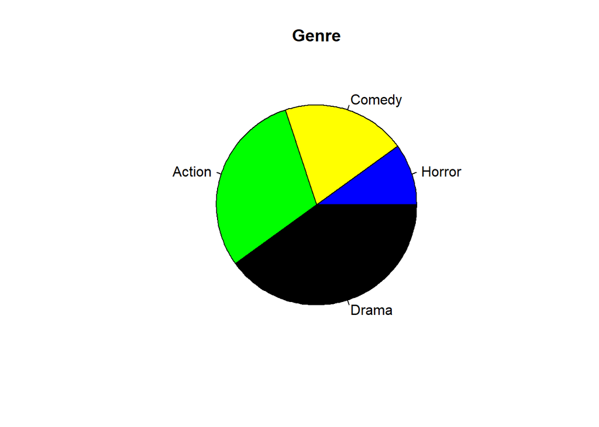

```r
# Create a vector of colors
colors <- c("blue", "yellow", "green", "black")

# Display the pie chart with colors
pie(x, label = movie_genre, main = "Genre", col = colors)
```

# Legend

To add a list of explanation for each pie, use the legend() function:

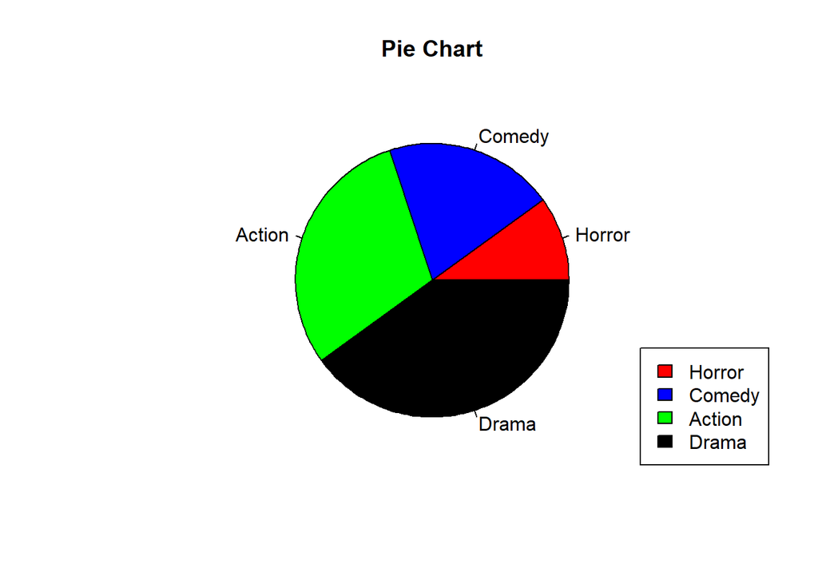

```r
# Create a vector of labels
movie_genre <- c("Horror", "Comedy", "Action", "Drama")

# Create a vector of colors
colors <- c("red", "blue", "green", "black")

# Display the pie chart with colors
pie(x, label = movie_genre, main = "Pie Chart", col = colors)

# Display the explanation box
legend("bottomright", movie_genre, fill = colors)
```

# Bar Charts

A bar chart uses rectangular bars to visualize data. Bar charts can be displayed horizontally or vertically. The height or length of the bars are proportional to the values they represent.

Use the barplot() function to draw a vertical bar chart:

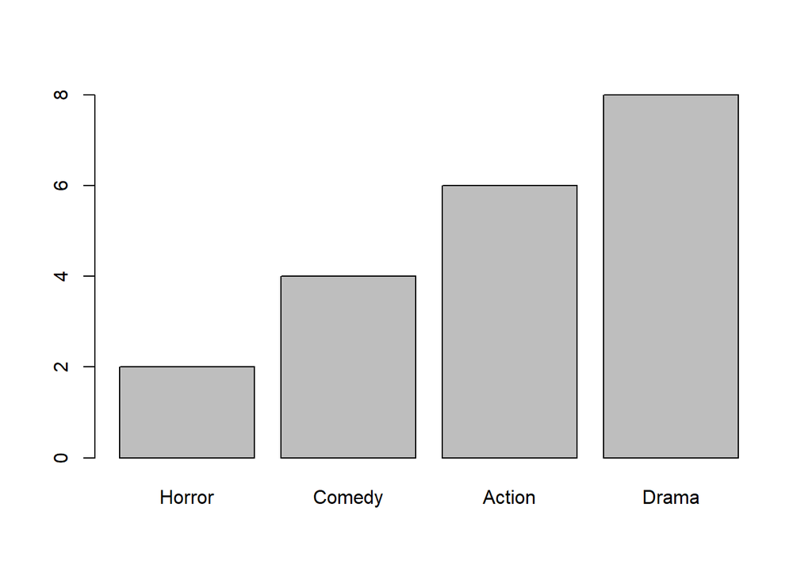

```r
# x-axis values
x <- c("Horror", "Comedy", "Action", "Drama")

# y-axis values
y <- c(2, 4, 6, 8)

barplot(y, names.arg = x)
```

# Bar Color

Use the col parameter to change the color of the bars:

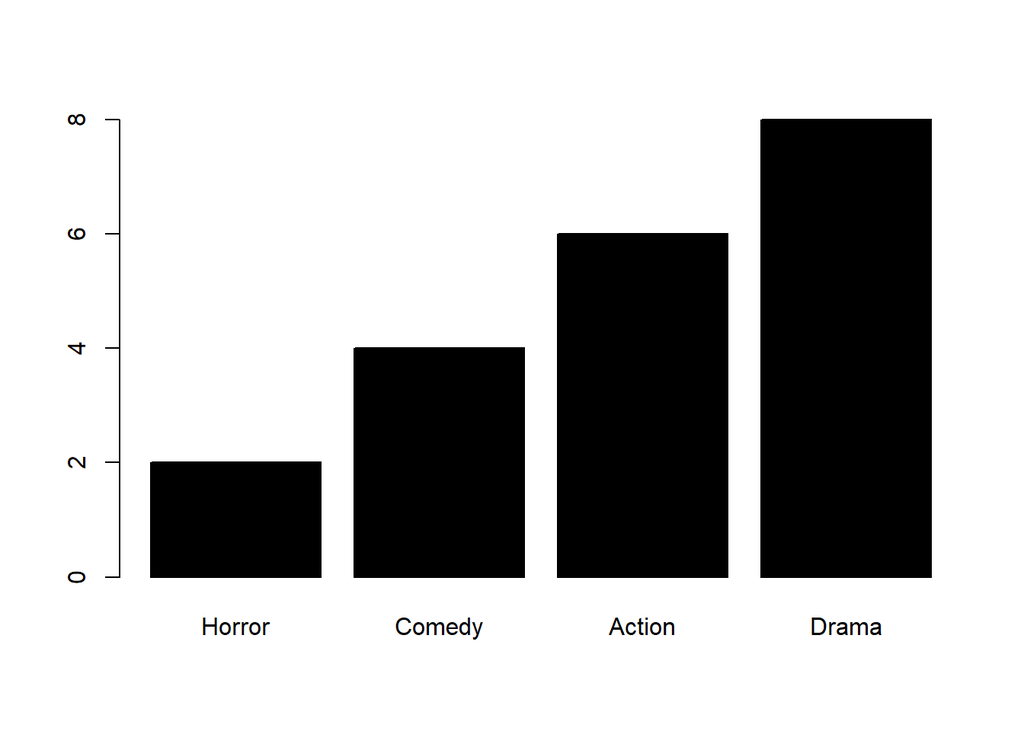

```r
x <- c("Horror", "Comedy", "Action", "Drama")
y <- c(2, 4, 6, 8)

barplot(y, names.arg = x, col = "black")
```

# Density / Bar Texture

To change the bar texture, use the density parameter:

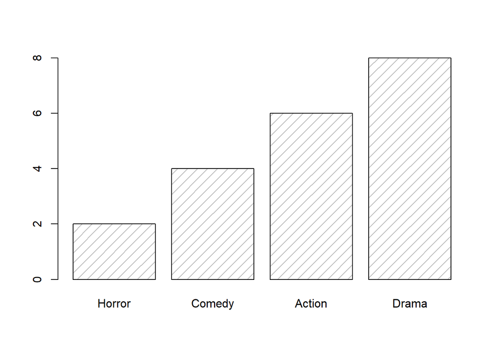

```r
x <- c("Horror", "Comedy", "Action", "Drama")
y <- c(2, 4, 6, 8)

barplot(y, names.arg = x, density = 10)
```

# Bar Width

Use the width parameter to change the width of the bars:

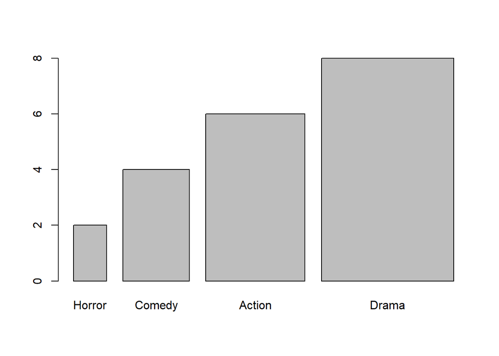

```r
x <- c("Horror", "Comedy", "Action", "Drama")
y <- c(2, 4, 6, 8)

barplot(y, names.arg = x, width = c(1,2,3,4))
```

# Horizontal Bars

If you want the bars to be displayed horizontally instead of vertically, use horiz=TRUE:

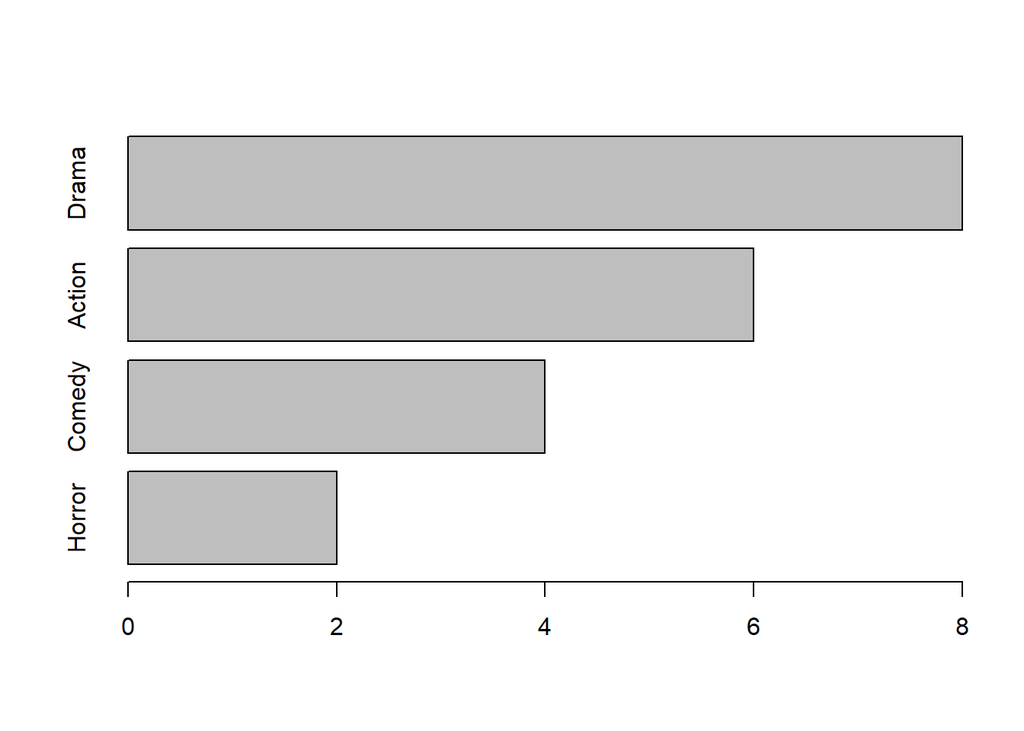

```r
x <- c("Horror", "Comedy", "Action", "Drama")
y <- c(2, 4, 6, 8)

barplot(y, names.arg = x, horiz = TRUE)
```